# Dem 11.36

Muhammad Reza Fahlevi

# Problems

The dataset consists of variable relating to blood pressure of 15 Peruvians ($n = 15$) who have moved from rural, high- altitude areas to urban, lower altitude areas. The variables in this data sets are: Systolic blood pressure ($Y$), weight ($X_1$), height ($X_2$), and pulse.

| Weight_kg | Heigh_mm | Pulse_per_minute | Systolic_pressure_mmHg |
| --- | --- | --- | --- |
| 71.0 | 1629 | 88 | 170 |
| 56.5 | 1569 | 64 | 120 |
| 56.0 | 1561 | 68 | 125 |
| 61.0 | 1619 | 52 | 148 |
| 65.0 | 1566 | 72 | 140 |
| 62.0 | 1639 | 72 | 106 |
| 53.0 | 1494 | 64 | 120 |
| 53.0 | 1568 | 80 | 108 |
| 65.0 | 1540 | 76 | 124 |
| 57.0 | 1530 | 60 | 134 |

[output cut: 5 more lines]

1. Determine if weight and systolic blood pressure are in a linear relationship, that is, test whether $H_0 : \beta_{1.0} = 0$, where $\beta_1$ is the slope of the regressor variable.
2. Perform a lack-of-ﬁt test to determine if linear relationship between weight and systolic blood pressure is adequate. Draw conclusions.
3. Determine if pulse rate inﬂuences systolic blood pressure in a linear relationship. Which regressor variable is the better predictor of the systolic blood pressure?

# Demonstrandum

Let

$$\begin{align}
x_1 &\stackrel{def} = \text{weight} \\
x_2 &\stackrel{def} = \text{height} \\
p &\stackrel{def} = \text{pulse}
\end{align}$$
The simple linear regression for given data $\{(x_i, y_i) : i = 1, 2, \ldots, n\}$ is defined as

$$Y = \beta_0 + \beta_1x$$
$Y$ is estimated by
$$\hat{y} = b_0 + b_1x$$
where $b_0$ and $b_1$ are regression’s coefficient estimator for $\beta_0$ and $\beta_1$, respectively. These estimator is computed as follows,

$$
$$\begin{align}
b_0 &= \frac{n\sum_{i = 1}^{n}x_iy_i - \sum_{i = 1}^{n}x_i\sum_{i = 1}^{n}y_i}
{n\sum_{i = 1}^{n}x_i^2 - \left(\sum_{i = 1}^{n}x_i\right)^2}, &\text{and} \\
b_1 &= \frac{\sum_{i = 1}^{n}y_i - b_1\sum_{i = 1}^{n}x_i}{n}
\end{align}$$
$$

## Take a Glimpse to the Data

The following output is the summarize of the given data

```
##    Weight_kg        Heigh_mm    Pulse_per_minute Systolic_pressure_mmHg
##  Min.   :53.00   Min.   :1486   Min.   :52.0     Min.   :106.0
##  1st Qu.:56.75   1st Qu.:1550   1st Qu.:62.0     1st Qu.:117.0
##  Median :62.00   Median :1569   Median :68.0     Median :124.0
##  Mean   :61.51   Mean   :1580   Mean   :69.6     Mean   :127.4
##  3rd Qu.:65.00   3rd Qu.:1626   3rd Qu.:74.0     3rd Qu.:136.0
##  Max.   :71.00   Max.   :1648   Max.   :88.0     Max.   :170.0
```

## Hypothesis Testing on the Slope for Regressor Variable $x_1$

The hypothesis that’s being tested is the slope of the regression line $\hat{y} = \beta_0 + \beta_1x$

$$\begin{cases}
H_0:\beta_{1.0} = 0 \\
H_1:\beta_{1.1} \neq 0 \\
\end{cases}$$

In order to make decision with regards to the hypothesis, the analysis of variances is performed.

**Step 1.** Construct the linear model for $X_1$,

```
##
## Call:
## lm(formula = "Systolic_pressure_mmHg~Weight_kg", data = dem_11_36)
##
## Coefficients:
## (Intercept)    Weight_kg
##      44.398        1.349
```

then for $\hat{y} = b_0 + b_1x_1$,
$$\hat{y} = 44.398 + 1.349x_1$$

**Step 2.** Compute the *one-way ANOVA*

```r
anova(lmodels_X1)
```

|  | Df | Sum Sq | Mean Sq | F value | Pr(>F) |
| --- | --- | --- | --- | --- | --- |
| Weight_kg | 1 | 805.8589 | 805.8589 | 3.364495 | 0.08959975 |
| Residuals | 13 | 3113.7411 | 239.5185 | NA | NA |

**Step 3.** Conclusion. Let $\alpha = 0.05$, the critical value for $f_\alpha(1, n-2)$

```
## [1] 4.667193
```

According to *one-way ANOVA* tables, the computed f-values $f_\text{reg} = 3.3645$. Hence, $f_\text{reg} < f_{0.05}(1, 13)$. Therefore, the hypothesis testing lead to *do not reject $H_0 : \beta_{1.0} = 0$ at $\alpha=0.05$ level of significance*.

## ANOVA for Testing Linearity of Regression $Y \sim x_1$

In order to determine the linear relationship between weight ($x_1$) and the systolic blood pressure ($Y$) is adequate or not, the *ANOVA for testing linearity of regression* is performed.

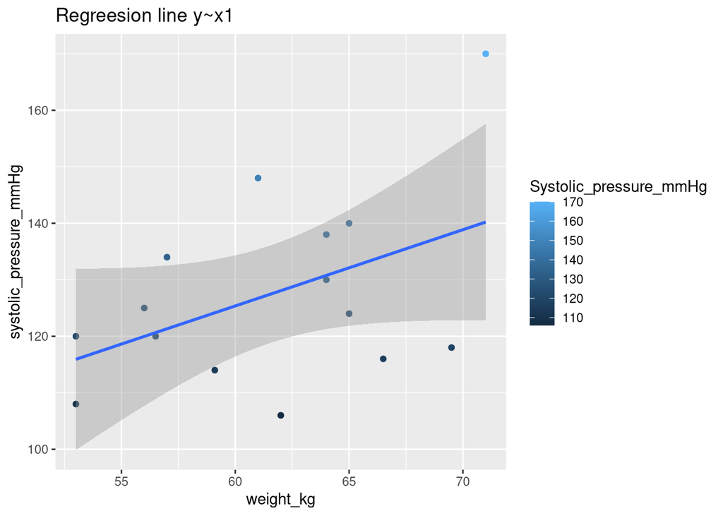

**Step 1.** Compute the sum of square $\text{SSR, SSE, SSE(pure)}$ and lack-of-fit. The $\text{SSR}$ is computed as follows,
$$\begin{align}
\text{SSR} &= \sum_{i = 1}^{n}(\hat{y_i} - \bar{y})^2 \\
&= 805.86
\end{align}$$

on $1$ degrees of freedom. The $\text{SSE}$ is computed as follows,
$$\begin{align}
\text{SSE} &= \sum_{i = 1}^{n}(y_i - \hat{y_i})^2 \\
&= 3113.74
\end{align}$$

on $n-2=13$ degrees of freedom. For data which contain $k$-groups, the $\text{SSE(pure)}$ is computed as follows,
$$\begin{align}
\text{pure error } &:=
\sum_{i = 1}^{k}\sum_{j = 1}^n (y^{(i)}_j - \bar{y}^{(i)})^2
\end{align}$$
where

$$\bar{y}^{(i)} = \frac{1}{n_i}\sum_{j = 1}^{n_i}y^{(i)}_j$$

for $i = 1, 2, \ldots, k$ and $j = 1, 2, \ldots, n_i$. In order to compute the pure error, the data must be group by the regressor variable $(x_1)$.

| Weight_kg | Systolic_pressure_mmHg |
| --- | --- |
| 53.0 | 120 |
| 53.0 | 108 |
| 56.0 | 125 |
| 56.5 | 120 |
| 57.0 | 134 |
| 59.1 | 114 |
| 61.0 | 148 |
| 62.0 | 106 |
| 64.0 | 130 |
| 64.0 | 138 |

[output cut: 5 more lines]

then

| Weight_kg | mean_y_ith | sum_sqr_y_ith |
| --- | --- | --- |
| 53.0 | 114 | 72 |
| 56.0 | 125 | 0 |
| 56.5 | 120 | 0 |
| 57.0 | 134 | 0 |
| 59.1 | 114 | 0 |
| 61.0 | 148 | 0 |
| 62.0 | 106 | 0 |
| 64.0 | 134 | 32 |
| 65.0 | 132 | 128 |
| 66.5 | 116 | 0 |

[output cut: 2 more lines]

from the tables, $k = 12$ groups, the second column is equals to $\bar{y}^{(i)}$, the third column is the value of
$$\sum_{j = 1}^{n_i}(y^{(i)}_j - \bar{y}^{(i)})$$
and the sum of third column is equals to the so called $\text{pure error}$, thus,
$$\text{pure error} := 232.00$$
on $n - k = 3$ degrees of freedom.

The differences between $\text{SSE}$ and $\text{SSE(pure)}$ is equals to the so called *lack-of-fit*, hence,
$$\begin{align}
\text{lack-of-fit} := \text{SSE} - \text{SSE(pure)} &=
\sum_{i = 1}^{n}(y_i - \hat{y}_i)^2 -
\sum_{i = 1}^k \sum_{j = 1}^{n_i}(y^{(i)}_j - \bar{y}^{(i)})^2 \\
&= 3113.74 - 232.00 \\
&= 2881.74
\end{align}$$
on $k - 2 = 10$ degrees of freedom.

**Step 2.** Compute the mean square for $\text{SSE}, \text{SSE(pure)}$ and $\text{lack-of-fit}$. The mean square for $\text{SSE}$,
$$\begin{align}
s^2 &= \frac{\text{SSE}}{n - 2} =
\sum_{i = 1}^{n} \frac{(y_i - \hat{y}_i)^2}{n - 2} =
\frac{S_{yy} - b_1S_{xy}}{n - 2} \\
&= \frac{3113.74}{15 - 2} = \frac{3113.74}{13} \\
s^2 &= 239.52
\end{align}$$

The mean square for *pure-error*,
$$\begin{align}
s^2_{\text{pure}} &= \frac{\text{pure error}}{n - k} =
\sum_{i = 1}^{k}\sum_{j = 1}^{n_i} \frac{(y^{(i)}_j -
\bar{y}^{(i)})^2}{n - k} \\
&= \frac{232.00}{15 - 12} \\ &= \frac{232.00}{3} \\
s^2_{\text{pure}} &= 77.33
\end{align}$$

The mean square for *lack-of-fit*,
$$\begin{align}
s^2_{\text{lack-of-fit}} &= \frac{\text{lack-of-fit}}{k - 2}
= \frac{\text{SSE} - \text{SSE(pure)}}{k - 2} \\
&= \frac{1}{k - 2} \left\{
\sum_{i = 1}^{n}(y_i - \hat{y}_i)^2 -
\sum_{i = 1}^{k} \sum_{j = 1}^{n_i}(y^{(i)}_j - \bar{y}^{(i)})^2
\right\} \\
&= \frac{3113.74 - 232.00}{12 - 2} \\
&= \frac{2881.74}{10} \\
s^2_{\text{lack-of-fit}} &= 288.17
\end{align}$$

on 1 and $n - 2 = 13$ degrees of freedom, and for $f_\text{lack-of-fit}$,
$$\begin{align}
f_\text{lack-of-fit} &= \frac{\text{lack-of-fit}}{s^2_\text{pure}(k - 2)} \\
&= \frac{\text{SSE} - \text{SSE(pure)}}{s^2_\text{pure}(k - 2)} \\
&= \frac{2881.74}{77.33 \times (12 - 2)} \\
&= \frac{2881.74}{77.33 \times 10} \\
&= \frac{2881.74}{773.3} \\
f_\text{lack-of-fit} &= 3.7264
\end{align}$$
on $k - 2 = 10$ and $n - k = 3$ degrees of freedom.

**Step 4.** Compute the P-values

[output not shown]

```
## [1] "P-values for f_lack-of-fit :=  0.153221390704174"
```

**Step 5.** Summarize altogether computation as table of *ANOVA for testing for linearity of regression.*

```r
EnvStats::anovaPE(lmodels_X1)
```

|  | Df | Sum Sq | Mean Sq | F value | Pr(>F) |
| --- | --- | --- | --- | --- | --- |
| Weight_kg | 1 | 805.8589 | 805.85886 | 10.420589 | 0.0482858 |
| Lack of Fit | 10 | 2881.7411 | 288.17411 | 3.726389 | 0.1532219 |
| Pure Error | 3 | 232.0000 | 77.33333 | NA | NA |

## ANOVA for Testing Linearity of Regression $Y \sim p$

As usual, in order to determine the linear relationship between pulse rate ($p$) and the systolic blood pressure ($Y$) is adequate or not, the *Analysis of Variances for testing linearity of regression* is performed.

**Step 1.** Construct the linear model $\hat{y} = b_0 + b_1p$

```
##
## Call:
## lm(formula = "Systolic_pressure_mmHg~Pulse_per_minute", data = dem_11_36)
##
## Coefficients:
##      (Intercept)  Pulse_per_minute
##         117.0641            0.1485
```

therefore,
$$\hat{y} = 117.0641 + 0.1485p$$

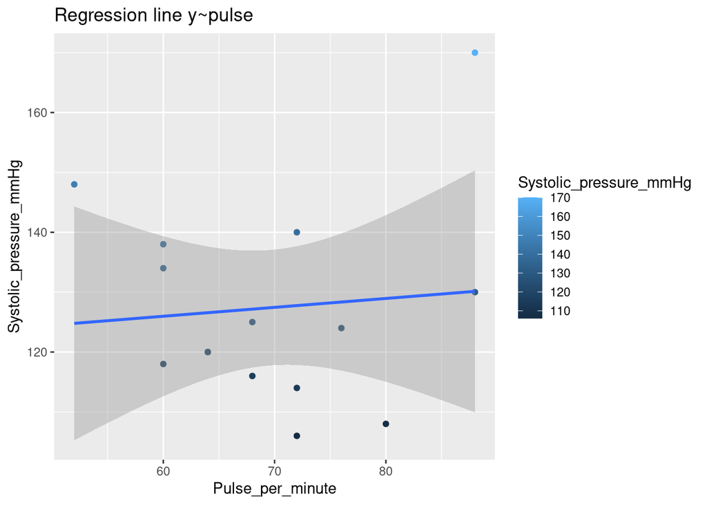

**Step 2.** Compute the $\text{SSR}$, $\text{SSE}$, $\text{pure-error}$, and $\text{lack-of-fit}$.

**Step 3.** Compute the mean square error for $\text{SSE}$, $\text{pure-error}$, and $\text{lack-of-fit}$.

**Step 4.** Compute the $f$-value for regression and $\text{lack-of-fit}$.

**Step 5.** Compute the $P\text{-values}$ for $f_{\text{reg}}$ and $f_{\text{lack-of-fit}}$

**Step 6.** Summarize altogether results into table of *ANOVA for testing linearity of regression*.

```r
EnvStats::anovaPE(lmodels_pulse)
```

|  | Df | Sum Sq | Mean Sq | F value | Pr(>F) |
| --- | --- | --- | --- | --- | --- |
| Pulse_per_minute | 1 | 33.02735 | 33.02735 | 0.1362755 | 0.7229254 |
| Lack of Fit | 6 | 2190.07265 | 365.01211 | 1.5060918 | 0.3007204 |
| Pure Error | 7 | 1696.50000 | 242.35714 | NA | NA |

## Hypothesis Testing on the Slope for Regressor Variable $x_2$

The hypothesis that’s being tested is the slope of the regression line $\hat{y} = \beta_0 + \beta_1x_2$, such that
$$\begin{cases}
H_0:\beta_{1.0} = 0 \\
H_1:\beta_{1.1} \neq 0
\end{cases}$$

in order decide which hypothesis should be chosen, the *one-way analysis of variances* is used.

**Step 1.** Construct the linear model $\hat{y} = b_0 + b_1x_2$.

```
##
## Call:
## lm(formula = "Systolic_pressure_mmHg~Heigh_mm", data = dem_11_36)
##
## Coefficients:
## (Intercept)     Heigh_mm
##     0.80328      0.08014
```

therefore,
$$\hat{y} = 0.80328 + 0.08014x_2$$

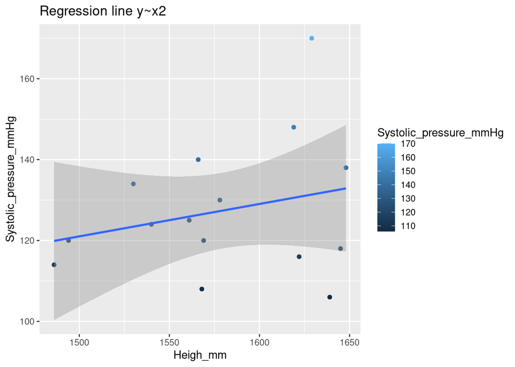

**Step 2.** Compute the $\text{SSR}$ and $\text{SSE}$.

**Step 3.** Compute the $f\text{-values}$.

**Step 4.** Compute the $P\text{-values}$.

**Step 5.** Summarize altogether computation as table of *One-way ANOVA*.

|  | Df | Sum Sq | Mean Sq | F value | Pr(>F) |
| --- | --- | --- | --- | --- | --- |
| Heigh_mm | 1 | 251.6066 | 251.6066 | 0.891737 | 0.3622279 |
| Residuals | 13 | 3667.9934 | 282.1533 | NA | NA |

**Step 6 (Conclusion).** Let $\alpha = 0.05$, recal the critical value for $f_\alpha(1, n - 2)$ or $f_\alpha(1, 13)$. From the table of one-way ANOVA, $f\text{-values} > f_\alpha(1,13)$ is **false**. Therefore, there are insignificant amount of variation accounted for by linear model (*do not reject* $H_0 : \beta_{1.0} = 0$).

## Determine Which Regressor Variable is the Better Predictor of $Y$

Visualize altogether linear models

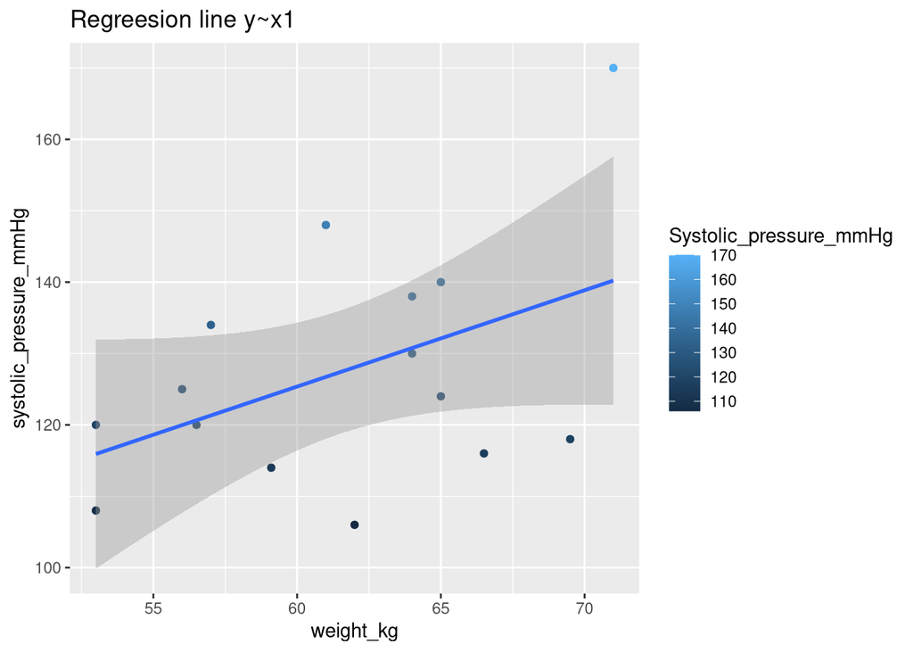

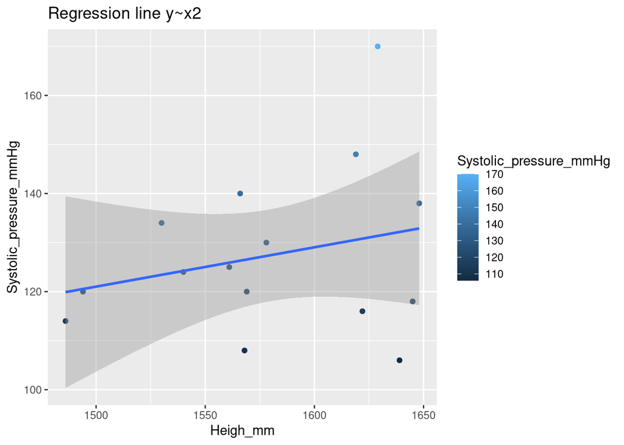

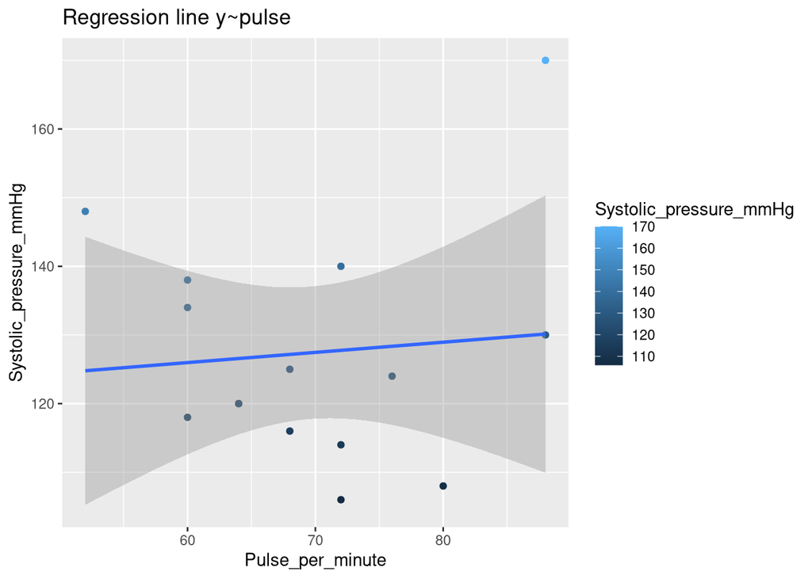

With regards to which regressor variable is better, from the computed $P\text{-values}$ after performed ANOVA for variable $x_1, x_2$ and $p$, for regressor variable $x$, $P\text{-values} \approx 0$, then $x$ is a better regressor variable for $Y$. Therefore, variable weight $(x_1)$ is better regressor variable for predictor of the systolic blood pressure $(Y)$, with $P\text{-values} = 0.04829$.